# Shuffle GSEA

Stephanie J. Spielman

2025-02-12

The purpose of this notebook is to assess how many pathways tend to come back significant from a GSEA analysis *where the gene sets have been shuffled*. This allows us to assess whether this analysis is appropriate for our data.

- This notebook will check this for the H gene sets from `MSigDB`.
- This notebook will perform analyses on models from data filtered with this expression threshold: 0.25.

## Setup

```r
renv::load()

library(ggplot2)
library(clusterProfiler)
theme_set(theme_bw())
set.seed(2025)
```

### Paths

```r
model_dir <- here::here("analysis", "pseudobulk-bulk-prediction", "results", "models")
ensembl_symbol_df <- readr::read_tsv(
  here::here("analysis", "bulk-deconvolution", "data", "reference", "ensembl_symbol.tsv"),
  show_col_types = FALSE
)
```

## Read and prepare data

```r
# get file extensions based on model_expr_threshold
ext_str <- ifelse(params$model_expr_threshold < 0, "all-genes", glue::glue("threshold-{params$model_expr_threshold}"))
```

```r
model_files <- list.files(
  path = model_dir,
  full.names = TRUE,
  pattern = paste0(ext_str, "\\.rds$")
) |>
  purrr::set_names(
    \(f) stringr::str_split_i(basename(f), pattern = "_", i = 1)
  )

n_projects <- 5
stopifnot(
  "Model files not found. Check the provided model file extension." = length(model_files) == n_projects
)

ranked_residuals_list <- model_files |>
  purrr::map(
  \(f) {
    model_data <- readr::read_rds(f)

    model_df <- model_data |>
      purrr::pluck("data") |>
      dplyr::mutate(residuals = unname(resid(model_data$model))) |>
      # get a ranked list
      dplyr::group_by(ensembl_id) |>
      dplyr::summarize(median_res = median(residuals)) |>
      dplyr::arrange(-median_res) |>
      dplyr::pull(median_res, name = ensembl_id)
  }
)
```

## Prepare shuffled gene sets

Define the gene set:

```r
msigdbr::msigdbr_collections() |>
  dplyr::filter(gs_cat == params$msigdbr_category)
```

| gs_cat | gs_subcat | num_genesets |
| --- | --- | --- |
| H |  | 50 |

```r
geneset_df <- msigdbr::msigdbr(species = "Homo sapiens", category = params$msigdbr_category)
```

```r
geneset_count_df <- geneset_df |>
  dplyr::count(gs_name)

unique_ensembl_ids <- geneset_df |>
  dplyr::distinct(human_ensembl_gene) |>
  dplyr::pull(human_ensembl_gene)
```

We’ll create 50 shuffled versions of the gene sets.

```r
# Create a shuffled version of genesets
generate_shuffle <- function(geneset_count_df, ensembl_ids){
  geneset_count_df |>
    purrr::pmap(
    \(gs_name, n) {
      data.frame(
        gs_name = gs_name,
        ensembl_id = sample(ensembl_ids, n) # no replacement!
      )
  }) |>
  purrr::list_rbind()
}

shuffled_geneset_df <- 1:params$reps |>
  purrr::map(
    \(i) {generate_shuffle(geneset_count_df, unique_ensembl_ids)}
  )

# Ensure correct lengths
purrr::walk(
  shuffled_geneset_df,
  \(df) {stopifnot(nrow(df) == nrow(geneset_df))}
)
```

## Perform GSEA

Next, we’ll run GSEA on them all:

(This next chunk takes a little bit to run; we’ll turn off messages and warnings since this is quite a lot of GSEAs!)

```r
shuffled_gsea_df <- ranked_residuals_list |>
  purrr::map(
  \(ranked_genes) {

    purrr::map(
      shuffled_geneset_df,
      \(shuffled_rep) {
        gsea_result <- clusterProfiler::GSEA(
          geneList = ranked_genes,
          TERM2GENE = shuffled_rep
        )
        gsea_result@result |>
          dplyr::summarize(
            bulk_enriched = sum(NES > 0),
            pseudobulk_enriched = sum(NES < 0)
          )
      }
    ) |> purrr::list_rbind(names_to = "rep")

  }) |>
  purrr::list_rbind(names_to = "project_id") |>
  # format data for plotting
  tidyr::pivot_longer(
    contains("enriched"),
    names_to = "direction",
    values_to = "count"
  ) |>
  # pseudobulk should be first
  dplyr::mutate(direction = forcats::fct_rev(direction))
```

## Visualize number of significant pathways

Finally, we’ll make a histogram of how many signficant gene sets were identified across the 50 replicates. Note that this data considers all results GSEA deemed to be signficant; there is no further filtering by effect size or P-value at this time.

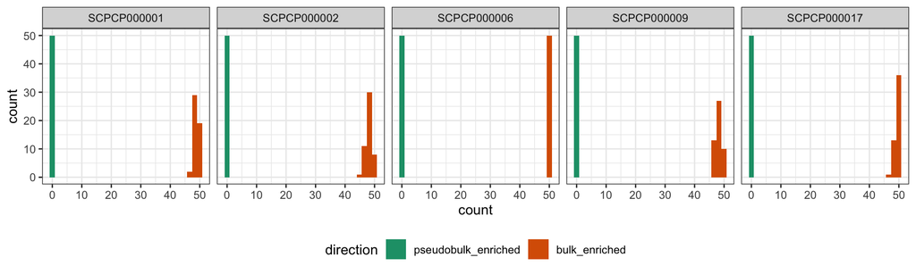

```r
ggplot(shuffled_gsea_df) +
  aes(x = count, fill = direction) +
  geom_histogram() +
  facet_wrap(vars(project_id), nrow = 1) +
  scale_fill_brewer(palette = "Dark2") +
  theme(legend.position = "bottom")
```